# Parameterized Reports Using R Markdown

## Overview

- Reporting analyses has become very customizable with the help of R Markdown. Users can write code, text, and display results all within the same document.

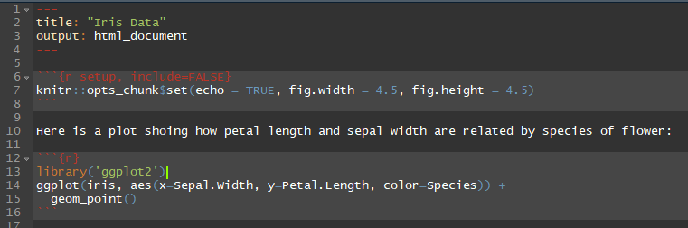

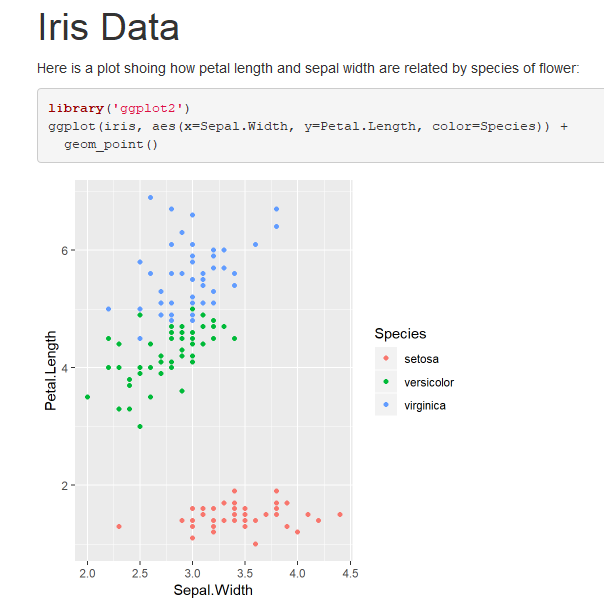

- There is a lot of customizability around how the report is displayed, such as whether or not the user wants to evaluate a certain chunk of code, or whether the user wants the chunk of code to be seen or not, etc.

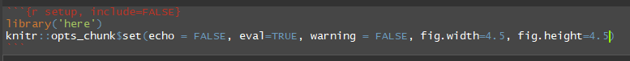

*Incorporating **parameters** into an R Markdown document can take customizability a step further.*

**Parameters** allow users to run the same report across different scenarios:

- **Showing the results for different diagnoses**
- **Selecting certain years for the report**
- **Showing results under different assumptions**
- **Changing the behavior of knitr**

## Incorporating Parameters

- Parameters are incorporated into the YAML section of the R Markdown document in the **'params'** field.

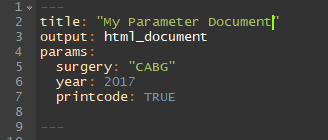

- R types that can be parsed by yaml::yaml.load() can be included as parameters (character, numeric, integer, logical)
- R objects can be included with '!r' before the R expression

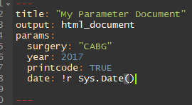

## Using Parameters

- Parameters can be accessed within a read-only list called **params**.
- Simply include 'params$' and the parameter to be accessed:

params$surgery  
params$year  
etc.

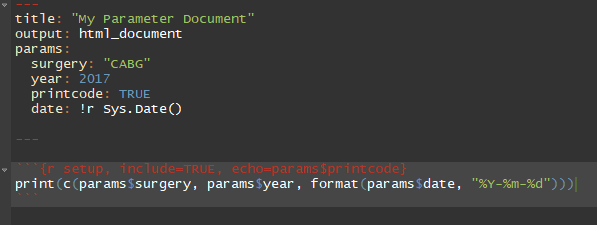

## Knitting

- Using the **'Knit'** button in RStudio
- Using **'rmarkdown::render()'**

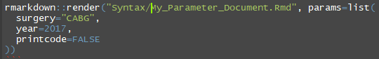

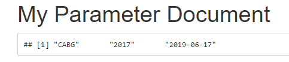

- Using an **interactive UI** for input of parameter values

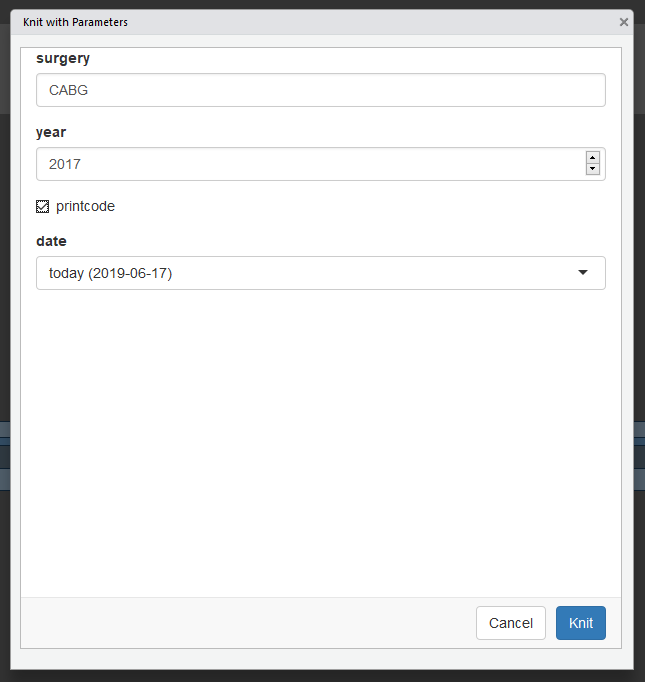

## The UI

The graphical user interface is based on Shiny. It's used to interactively select inputs for the report.

It can be accessed by:

- 'Knit' dropdown > 'Knit with Parameters' or
- rmarkdown::render("My_Parameter_Document.Rmd", params="ask")

*What if we wished to constrain 'year' to a certain range, or we wished to display discrete options for 'surgery'?*

- Inputs for parameters can be controlled by additional arguments in the YAML.
- The graphical UI has the ability to provide different features for input selection such as sliders, check boxes, text boxes.

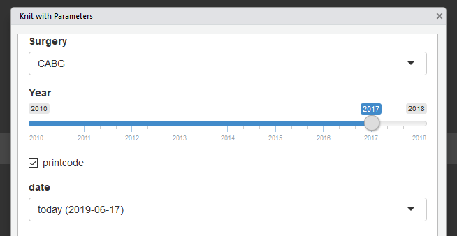

The Input field controls the type of feature. Below is a list of the different inputs currently supported.

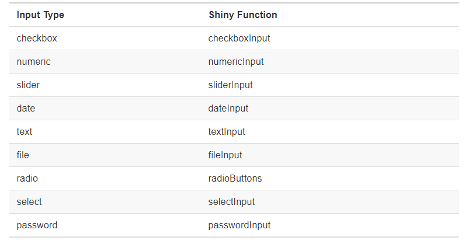

To create these features, sub-items can be specified under the parameters in the YAML:

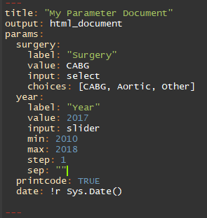

These interactive features are very helpful when others are accessing your report, such as with RStudio Connect (https://www.rstudio.com/products/connect/)

## Resources

https://bookdown.org/yihui/rmarkdown/parameterized-reports.html

https://docs.rstudio.com/connect/user/param-rmarkdown.html